# Rapport QAQC - Afrobarometer Sénégal

Round 9 · 2022 · Pipeline ENSAE Dakar

## 📊 Rapport QAQC - Afrobarometer Sénégal

Pipeline de traitement des données d’opinion - ENSAE Dakar

Ibrahim ADAM ALASSANE  
Moussa DIAKITE  
Fallou NGOM  
Cheikh Sadibou NGOM  
Gnalen SANGARE  
Seman Giovanni Jocelyn GADO  
Sié Rachid TRAORE  
*Superviseur : M. MBodj*

# 1 Vue d’ensemble

## 1.1 Taille des bases

Taille des bases - brute vs traitées

[output not shown]

## 1.2 Indicateurs clés

Les cartes ci-dessous résument en un coup d’oeil la taille de la base traitée, le nombre de variables disponibles et les principaux signaux d’alerte qualité détectés par le pipeline.

1 200

Individus

1 200

Ménages

32

Variables individus

29

Variables ménages

3

Alertes NA (>20 %)

4

Critiques NA (>50 %)

0

Anomalies

## 1.3 Contrôles de cohérence

Le tableau suivant présente les résultats des vérifications automatiques appliquées à la base : unicité des identifiants individus et ménages, et cohérence des âges déclarés (plage attendue : 15–120 ans).

Résultats des contrôles de cohérence

| Contrôle | Statut | Détail |
| --- | --- | --- |
| Unicité de id_individu (individus + ménages) | ✓ OK | 0 doublon(s) détecté(s) |
| Plage d’âge (15-120 ans) | ✓ OK | 0 valeurs hors plage détectées |

# 2 Qualité des données

## 2.1 Synthèse des valeurs manquantes

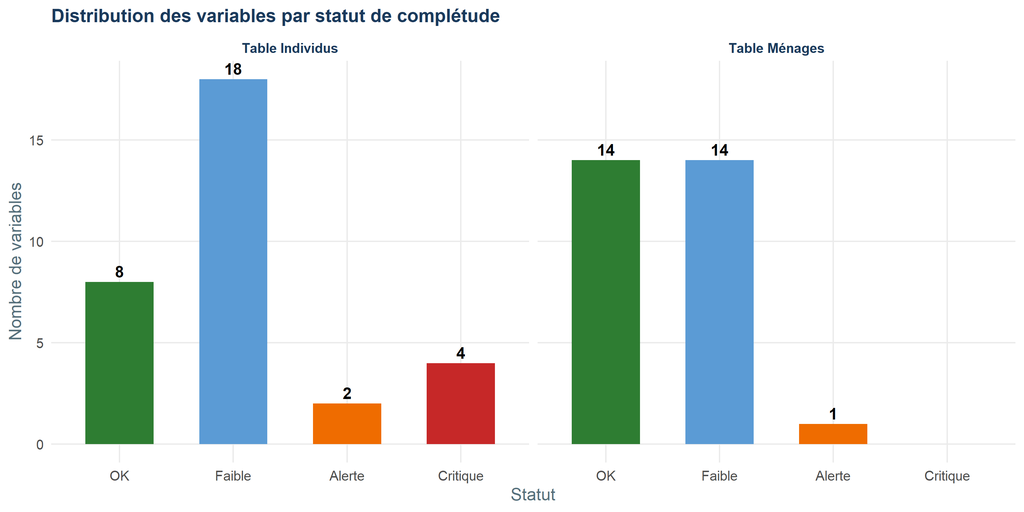

## 2.2 Variables à risque

Les onglets ci-dessous détaillent, pour chaque table, uniquement les variables présentant au moins une valeur manquante, triées du taux le plus élevé au plus faible.

### 2.2.1 Table individus

Complétude - Table individus

| Variable | N total | N manquant | % NA | Statut |
| --- | --- | --- | --- | --- |
| activite_secondaire_isic_section | 1200 | 1151 | 95,9 % | ⚠ Critique |
| activite_secondaire | 1200 | 1134 | 94,5 % | ⚠ Critique |
| activite_secondaire_isic_libelle | 1200 | 1134 | 94,5 % | ⚠ Critique |
| activite_principale_isic_section | 1200 | 644 | 53,7 % | ⚠ Critique |
| electricite_freq | 1200 | 330 | 27,5 % | ⚠ Alerte |
| activite_principale_isic_libelle | 1200 | 272 | 22,7 % | ⚠ Alerte |
| activite_principale | 1200 | 178 | 14,8 % | Faible |
| departement | 1200 | 136 | 11,3 % | Faible |
| score_actifs | 1200 | 119 | 9,9 % | Faible |
| niveau_etudes | 1200 | 117 | 9,8 % | Faible |
| internet | 1200 | 110 | 9,2 % | Faible |
| commune | 1200 | 87 | 7,2 % | Faible |
| arrondismt | 1200 | 72 | 6,0 % | Faible |
| source_eau | 1200 | 30 | 2,5 % | Faible |
| langue_domicile | 1200 | 21 | 1,8 % | Faible |
| radio | 1200 | 6 | 0,5 % | Faible |
| ordinateur | 1200 | 5 | 0,4 % | Faible |
| television | 1200 | 2 | 0,2 % | Faible |
| statut_emploi_principal | 1200 | 1 | 0,1 % | Faible |
| privation_revenus | 1200 | 1 | 0,1 % | Faible |
| vehicule | 1200 | 1 | 0,1 % | Faible |
| telephone | 1200 | 1 | 0,1 % | Faible |
| assainissement | 1200 | 1 | 0,1 % | Faible |
| electricite_acces | 1200 | 1 | 0,1 % | Faible |

### 2.2.2 Table ménages

Complétude - Table ménages

| Variable | N total | N manquant | % NA | Statut |
| --- | --- | --- | --- | --- |
| electricite_freq | 1200 | 330 | 27,5 % | ⚠ Alerte |
| departement | 1200 | 136 | 11,3 % | Faible |
| rep_niveau_etudes | 1200 | 117 | 9,8 % | Faible |
| commune | 1200 | 87 | 7,2 % | Faible |
| arrondismt | 1200 | 72 | 6,0 % | Faible |
| source_eau | 1200 | 30 | 2,5 % | Faible |
| rep_langue_domicile | 1200 | 21 | 1,8 % | Faible |
| indice_privation | 1200 | 2 | 0,2 % | Faible |
| groupe_privation | 1200 | 2 | 0,2 % | Faible |
| assainissement | 1200 | 1 | 0,1 % | Faible |
| electricite_acces | 1200 | 1 | 0,1 % | Faible |
| manque_nourriture | 1200 | 1 | 0,1 % | Faible |
| manque_revenus | 1200 | 1 | 0,1 % | Faible |
| prive_manque_nourriture | 1200 | 1 | 0,1 % | Faible |
| prive_manque_revenus | 1200 | 1 | 0,1 % | Faible |

### 2.2.3 Graphique comparatif

Ce graphique compare visuellement les taux de NA de toutes les variables (individus et ménages). Les lignes en pointillés indiquent les seuils d’alerte (20 %) et critique (50 %).

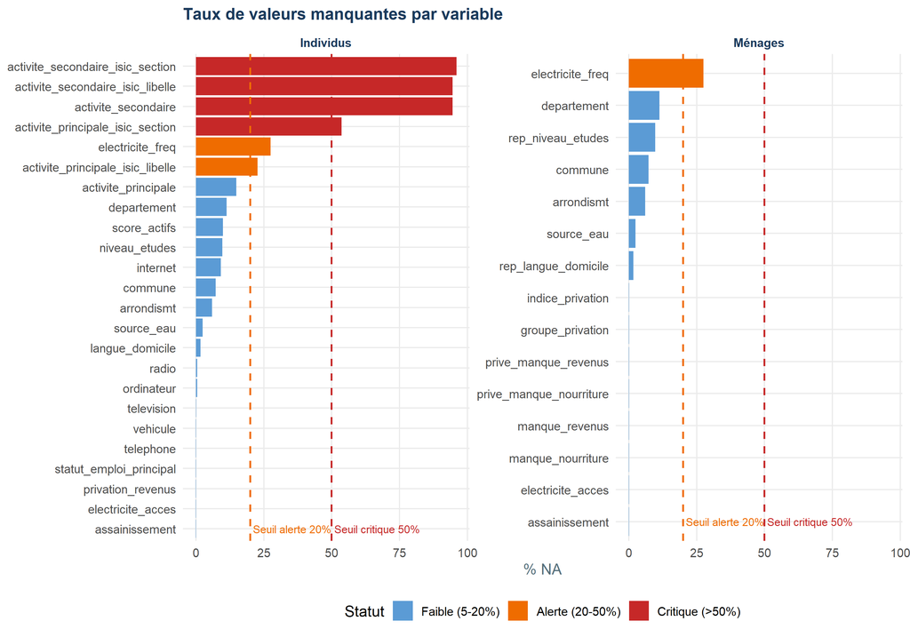

## 2.3 Valeurs aberrantes

Les valeurs aberrantes sont détectées par la méthode IQR × 3 : toute observation inférieure à Q1 − 3×IQR ou supérieure à Q3 + 3×IQR est signalée. Le graphique et le tableau ci-dessous listent les variables numériques concernées.

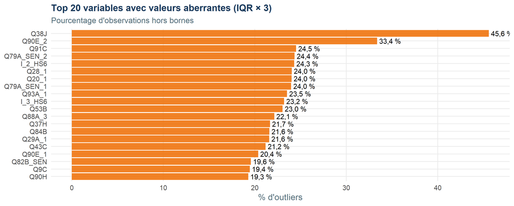

Détail des outliers détectés (méthode IQR × 3)

| Variable | N outliers | % | Min | Max | Borne inf. | Borne sup. |
| --- | --- | --- | --- | --- | --- | --- |
| Q38J | 512 | 45,59 % | 0,00 | 3,00 | 1,00 | 1,00 |
| Q90E_2 | 317 | 33,37 % | 0,00 | 2,00 | 1,00 | 1,00 |
| Q91C | 294 | 24,52 % | 0,00 | 3,00 | 1,00 | 1,00 |
| Q79A_SEN_2 | 291 | 24,35 % | 1,00 | 2,00 | 1,00 | 1,00 |
| I_2_HS6 | 35 | 24,31 % | 1,00 | 3,00 | 2,00 | 2,00 |
| Q28_1 | 288 | 24,04 % | 1,00 | 5,00 | 2,00 | 2,00 |
| Q20_1 | 288 | 24,02 % | 1,00 | 5,00 | 2,00 | 2,00 |
| Q79A_SEN_1 | 287 | 23,98 % | 1,00 | 5,00 | 1,00 | 1,00 |
| Q93A_1 | 282 | 23,52 % | 0,00 | 1,00 | 0,00 | 0,00 |
| I_3_HS6 | 13 | 23,21 % | 1,00 | 3,00 | 2,00 | 2,00 |
| Q53B | 273 | 23,04 % | 1,00 | 4,00 | 4,00 | 4,00 |
| Q88A_3 | 152 | 22,13 % | 1,00 | 2,00 | 1,00 | 1,00 |
| Q37H | 259 | 21,66 % | 0,00 | 3,00 | 3,00 | 3,00 |
| Q84B | 258 | 21,59 % | 0,00 | 3,00 | 0,00 | 0,00 |
| Q29A_1 | 258 | 21,57 % | 1,00 | 5,00 | 1,00 | 1,00 |
| Q43C | 18 | 21,18 % | 0,00 | 3,00 | 0,00 | 0,00 |
| Q90E_1 | 243 | 20,37 % | 0,00 | 1,00 | 0,00 | 0,00 |
| Q82B_SEN | 234 | 19,57 % | 0,00 | 1,00 | 0,00 | 0,00 |
| Q9C | 233 | 19,45 % | 1,00 | 4,00 | 4,00 | 4,00 |
| Q90H | 231 | 19,28 % | 0,00 | 4,00 | 4,00 | 4,00 |
| Q98A | 224 | 19,08 % | 0,00 | 1,00 | 1,00 | 1,00 |
| Q27A_1 | 227 | 18,96 % | 1,00 | 5,00 | 1,00 | 1,00 |
| Q56C_1 | 226 | 18,85 % | 1,00 | 3,00 | 3,00 | 3,00 |
| Q97 | 151 | 18,71 % | 0,00 | 95,00 | 1,00 | 1,00 |
| Q24_1 | 216 | 18,06 % | 1,00 | 5,00 | 1,00 | 1,00 |
| Q39A_2 | 155 | 17,90 % | 1,00 | 2,00 | 1,00 | 1,00 |
| Q81B_SEN_A | 89 | 17,02 % | 0,00 | 1,00 | 0,00 | 0,00 |
| Q107 | 200 | 16,67 % | 0,00 | 4,00 | 4,00 | 4,00 |
| Q72E_2 | 173 | 16,21 % | 4,00 | 5,00 | 5,00 | 5,00 |
| Q56_1 | 194 | 16,18 % | 1,00 | 3,00 | 3,00 | 3,00 |

[output cut: 125 more lines]

# 3 Estimations primaires

Les statistiques suivantes sont des **estimations primaires** calculées après traitement des données. Elles permettent de vérifier la cohérence globale de l’échantillon.

## 3.1 Profil sociodémographique

### 3.1.1 Genre

Ce graphique montre la répartition des répondants selon le genre. Il permet de vérifier l’équilibre de l’échantillon entre hommes et femmes.

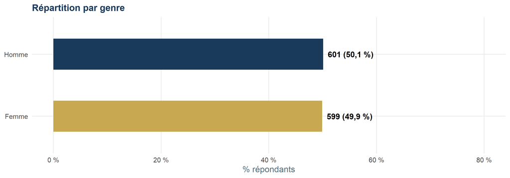

### 3.1.2 Niveau d’instruction

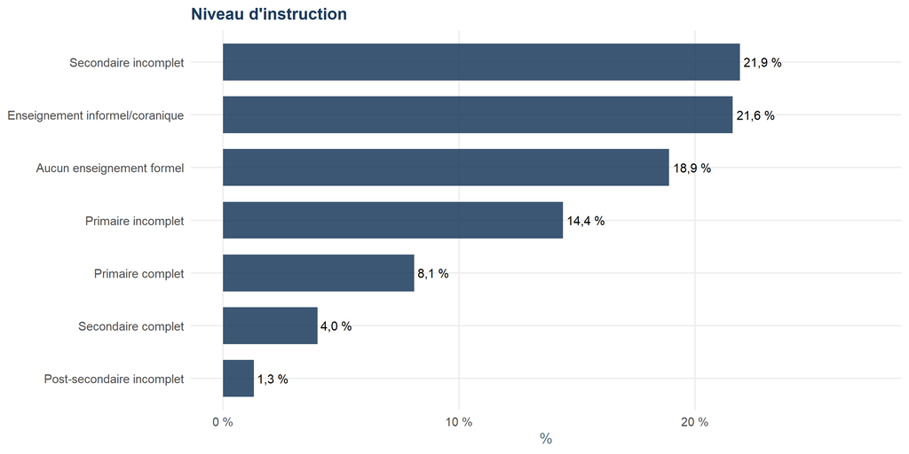

### 3.1.3 Milieu de résidence

Ce graphique compare la part des répondants résidant en milieu urbain versus rural, conformément à la stratification de l’enquête Afrobarometer.

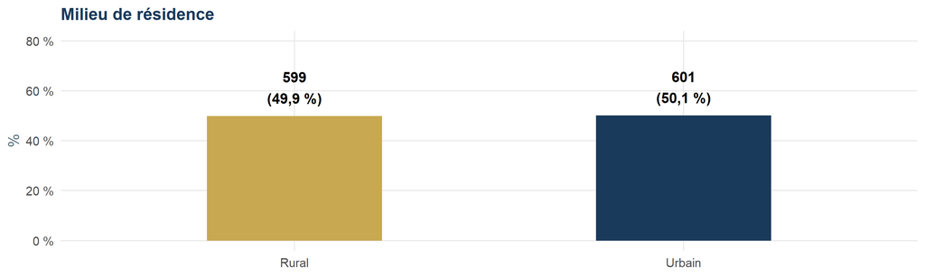

## 3.2 Couverture géographique

Ce graphique montre le nombre de répondants par région administrative du Sénégal. La couleur indique la densité de l’échantillon : faible (bleu clair), moyen ou fort (bleu foncé), afin de repérer les régions sous-représentées.

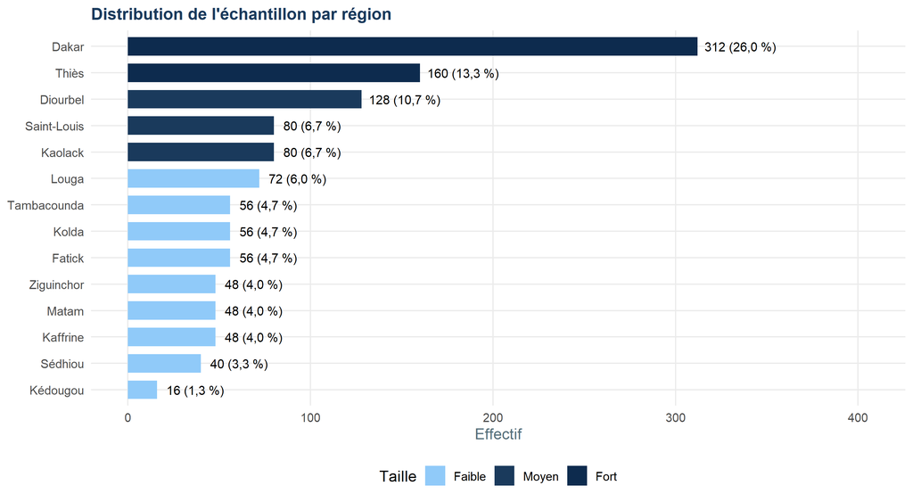

## 3.3 Profil économique

### 3.3.1 Statut d’emploi

Ce graphique présente la distribution des répondants selon leur situation vis-à-vis de l’emploi (salarié, indépendant, sans emploi, inactif, etc.), telle que déclarée lors de l’enquête.

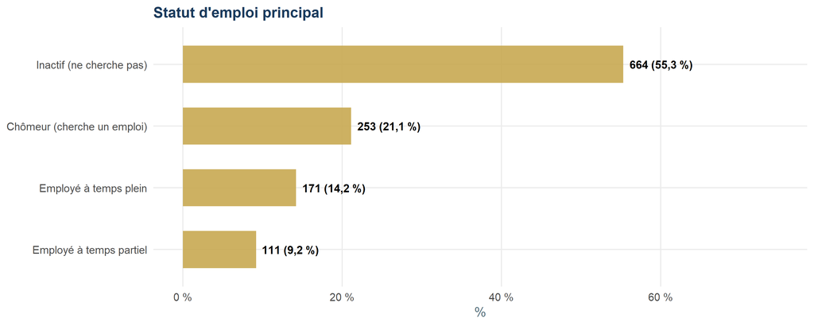

### 3.3.3 Score d’actifs

Les cartes ci-dessous résument les statistiques descriptives du score d’actifs, qui mesure le nombre de biens durables possédés par le répondant (de 0 à 6). Ce score est un proxy du niveau de vie du ménage.

4,00

Moyenne

4

Médiane

1,40

Écart-type

1 – 6

Min – Max

**Score d’actifs** : nombre de biens possédés parmi les 6 catégories collectées (radio, télévision, véhicule/moto, ordinateur, téléphone portable, accès internet).

## 3.4 Conditions de vie des ménages

Les indicateurs et le graphique suivants décrivent l’indice de privation composite des ménages, construit à partir de cinq dimensions (nourriture, eau, soins, combustible, revenus). Chaque dimension est comptée comme une privation si le répondant déclare en manquer au moins « quelques fois » dans l’année.

2,95

Indice moyen de privation

7,1 %

Sans aucune privation

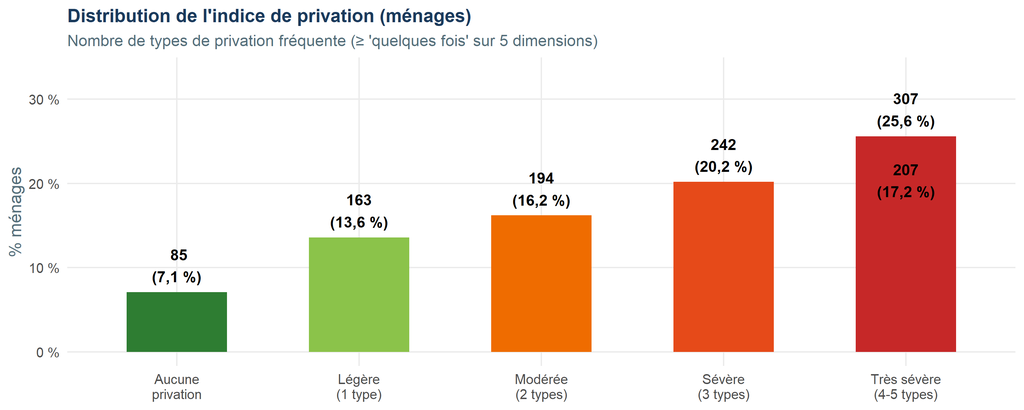

**Les 5 dimensions de privation mesurées :**  
Nourriture (Q6A) · Eau potable (Q6B) · Soins médicaux (Q6C) · Combustible (Q6D) · Revenus en espèces (Q6E)  
Seuil : réponse ≥ 2 (« quelques fois » ou plus fréquent au cours des 12 derniers mois).

**Pipeline Afrobarometer Sénégal** · ENSAE Dakar · ISE Fin de Formation  
Rapport généré automatiquement - Round 9 (2022)  
**Groupe :** Ibrahim ADAM ALASSANE · Moussa DIAKITE · Fallou NGOM · Cheikh Sadibou NGOM · Gnalen SANGARE · Seman Giovanni Jocelyn GADO · Sié Rachid TRAORE  
**Superviseur :** M. MBodj  
*Données : [Afrobarometer](https://www.afrobarometer.org/countries/senegal/)*